# Assignment 4 - dimensionality reduction

This assignment focuses on two different ways for dimensionality reduction:

- feature selection
- feature extraction

This assignment has weighting $1.5$.

# Sequential feature selection (50 points)

There is a sample code in PML chapter 4 for sequential bardward selection (SBS) and its application to subsequent KNN classifier.

Implement sequential forward selection (SFS), and compare it with sequential backward selection by plotting the accuracy versus the number of features.

You can start with the sample code provided in the [slides](http://nbviewer.jupyter.org/github/1iyiwei/pyml/blob/master/code/ch04/ch04.ipynb). You can extend the existing SBS class to handle both forward and backward selection, or implement a separate class for SFS. Plot and compare the two accuracy versus number-of-features plots for SFS and SBS.

Use the wine dataset as follows.

```python
import pandas as pd

wine_data_remote = 'https://archive.ics.uci.edu/ml/machine-learning-databases/wine/wine.data'
wine_data_local = '../datasets/wine/wine.data'

df_wine = pd.read_csv(wine_data_remote,
                      header=None)

df_wine.columns = ['Class label', 'Alcohol', 'Malic acid', 'Ash',
                   'Alcalinity of ash', 'Magnesium', 'Total phenols',
                   'Flavanoids', 'Nonflavanoid phenols', 'Proanthocyanins',
                   'Color intensity', 'Hue', 'OD280/OD315 of diluted wines',
                   'Proline']

#print('Class labels', np.unique(df_wine['Class label']))
#df_wine.head()
```

```python
from sklearn import __version__ as skv
from distutils.version import LooseVersion as CheckVersion
if CheckVersion(skv) < '0.18':
    from sklearn.cross_validation import train_test_split
else:
    from sklearn.model_selection import train_test_split

X, y = df_wine.iloc[:, 1:].values, df_wine.iloc[:, 0].values

X_train, X_test, y_train, y_test = \
    train_test_split(X, y, test_size=0.3, random_state=0)
```

```python
from sklearn.preprocessing import StandardScaler

stdsc = StandardScaler()
X_train_std = stdsc.fit_transform(X_train)
X_test_std = stdsc.transform(X_test)
```

## Answer

Apply your sequential forward/backward selection code to the KNN classifier with the wine data set, and plot the accuracy versus number-of-features curves for both. Describe the similarities and differences you can find, e.g.

- do the two methods agree on the optimal number of features?
- do the two methods have similar accuracy scores for each number of features?
- etc.

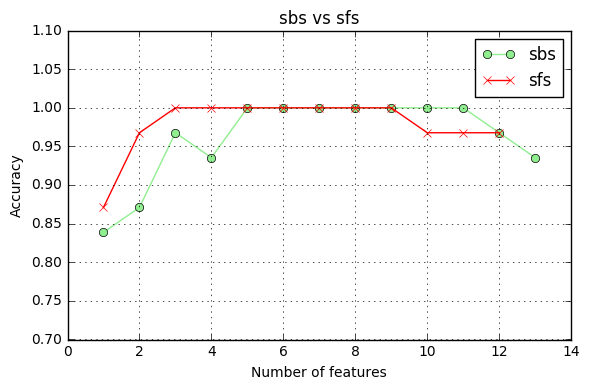

```python
%matplotlib inline
from sklearn.base import clone
from itertools import combinations
import numpy as np
from sklearn.metrics import accuracy_score

class SS():
    def __init__(self, estimator, k_features, scoring=accuracy_score,
                 test_size=0.25, random_state=1, mode=0):
        self.scoring = scoring
        self.estimator = clone(estimator)
        self.k_features = k_features
        self.test_size = test_size
        self.random_state = random_state
        # indicate forward or backward, if forward, mode = 1; if backward, mode = 0
        self.mode = mode

    def fit(self, X, y):

        X_train, X_test, y_train, y_test = \
            train_test_split(X, y, test_size=self.test_size,
                             random_state=self.random_state)
        if self.mode == 0:
            #backward selection

            dim = X_train.shape[1]
            self.indices_ = tuple(range(dim))
            self.subsets_ = [self.indices_]
            score = self._calc_score(X_train, y_train,
                                     X_test, y_test, self.indices_)
            self.scores_ = [score]

            while dim > self.k_features:
                scores = []
                subsets = []

                for p in combinations(self.indices_, r=dim - 1):
                    score = self._calc_score(X_train, y_train,
                                             X_test, y_test, p)
                    scores.append(score)
                    subsets.append(p)

                best = np.argmax(scores)
                self.indices_ = subsets[best]
                self.subsets_.append(self.indices_)
                dim -= 1

                self.scores_.append(scores[best])
        else:
            #forward selection
            dim = X_train.shape[1]
            self.indices_ = tuple(range(dim))
            self.subsets_ = [self.indices_]
            score = self._calc_score(X_train, y_train,
                                     X_test, y_test, self.indices_)
            self.scores_ = [score]

            # use 2 lists to keep track on used and unused values
            used = []
            remaining = []

            # init the unused list
            for i in range(0, X_train.shape[1]):
                remaining.append(i)

            for _ in range(dim-self.k_features):
                scores = []
                subsets = []

                for i in combinations(remaining, r=1):
                    temp = tuple(used + list(i))
                    score = self._calc_score(X_train, y_train,
                                             X_test, y_test, temp)
                    scores.append(score)
                    subsets.append(temp)

                best = np.argmax(scores)
                self.scores_.append(scores[best])
                best = remaining[best]
                used.append(best)
                remaining.remove(best)
                self.subsets_.append(tuple(used))

            self.indices_ = tuple(used)

            # remove the first duplicated value
            self.scores_.remove(self.scores_[0])
            self.subsets_.remove(self.subsets_[0])
        return self

    def transform(self, X):
        return X[:, self.indices_]

    def _calc_score(self, X_train, y_train, X_test, y_test, indices):
        self.estimator.fit(X_train[:, indices], y_train)
        y_pred = self.estimator.predict(X_test[:, indices])
        score = self.scoring(y_test, y_pred)
        return score

import matplotlib.pyplot as plt
from sklearn.neighbors import KNeighborsClassifier

knn = KNeighborsClassifier(n_neighbors=2)

dim = X_train.shape[1]
numOfFeatures = 1

# backward
sbs = SS(knn, k_features=numOfFeatures, mode=0)
sbs.fit(X_train_std, y_train)
# plotting performance of feature subsets
k_feat1 = [len(k) for k in sbs.subsets_]

# forward
sfs = SS(knn, k_features=numOfFeatures, mode=1)
sfs.fit(X_train_std, y_train)
# plotting performance of feature subsets
k_feat2 = [len(k) for k in sfs.subsets_]

plt.plot(k_feat1, sbs.scores_, marker='o', label='sbs', color='lightgreen')
plt.plot(k_feat2, sfs.scores_, marker='x', label='sfs', color='red')

plt.ylim([0.7, 1.1])
plt.ylabel('Accuracy')
plt.xlabel('Number of features')
plt.title('sbs vs sfs')
plt.legend(loc='best')
plt.grid()
plt.tight_layout()
# plt.savefig('./sbs.png', dpi=300)
plt.show()
```

# PCA versus LDA (50 points)

We have learned two different methods for feature extraction, PCA (unsupervised) and LDA (supervised).

Under what circumstances would PCA and LDA produce very different results?

Provide one example dataset in 2D, analyze it via PCA and LDA, and plot it with the PCA and LDA components.

You can use code from the scikit-learn library.

## Answer

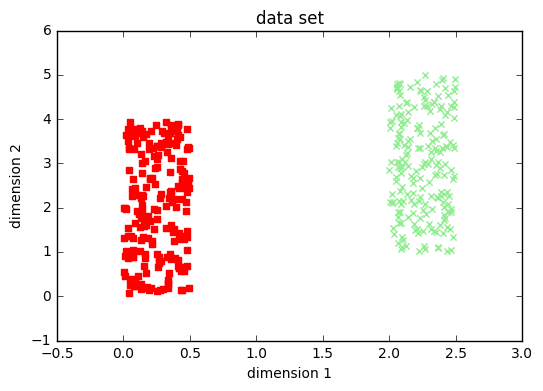

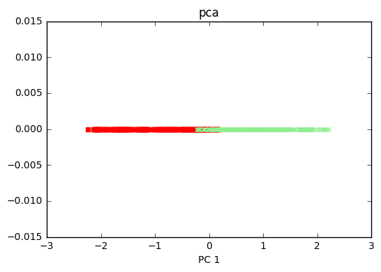

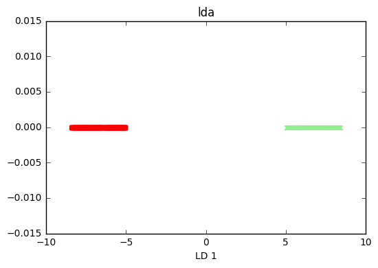

```python
%matplotlib inline

# from matplotlib.colors import ListedColormap

# def plot_decision_regions(X, y, classifier, resolution=0.02):

#     # setup marker generator and color map
#     markers = ('s', 'x', 'o', '^', 'v')
#     colors = ('red', 'blue', 'lightgreen', 'gray', 'cyan')
#     cmap = ListedColormap(colors[:len(np.unique(y))])

#     # plot the decision surface
#     x1_min, x1_max = X[:, 0].min() - 1, X[:, 0].max() + 1
#     x2_min, x2_max = X[:, 1].min() - 1, X[:, 1].max() + 1
#     xx1, xx2 = np.meshgrid(np.arange(x1_min, x1_max, resolution),
#                            np.arange(x2_min, x2_max, resolution))
#     Z = classifier.predict(np.array([xx1.ravel(), xx2.ravel()]).T)
#     Z = Z.reshape(xx1.shape)
#     plt.contourf(xx1, xx2, Z, alpha=0.4, cmap=cmap)
#     plt.xlim(xx1.min(), xx1.max())
#     plt.ylim(xx2.min(), xx2.max())

#     # plot class samples
#     for idx, cl in enumerate(np.unique(y)):
#         plt.scatter(x=X[y == cl, 0], y=X[y == cl, 1],
#                     alpha=0.8, c=cmap(idx),
#                     marker=markers[idx], label=cl)

import numpy as np

from sklearn import datasets
from sklearn.decomposition import PCA
# from sklearn.discriminant_analysis import LinearDiscriminantAnalysis as LDA
from sklearn.lda import LDA

iris = datasets.load_iris()

X_iris = iris.data
y_iris = iris.target
target_names = iris.target_names

import random

X = []
y = []

# my data set
# create data with label 0
for _ in range(0,200):
    xc = random.random()*0.5; #range of x is [0,0.5)
    yc = random.random()*4; #range of y is [0,4)
    pair = [xc,yc]
    X.append(pair)
    y.append(0)
# create data with label 1
for _ in range(0,200):
    xc = random.random()*0.5+2; #range of x is [2,2.5)
    yc = random.random()*4+1; #range of y is [1,5)
    pair = [xc,yc]
    X.append(pair)
    y.append(1)

# X = np.array([[0. ,0.],
#               [0.2 ,1.],
#               [0. ,2.],
#               [1. ,0.5],
#               [1.2 ,1.5],
#               [1. ,2.5]])
# y = np.array([0, 0, 0, 1, 1, 1])
X = np.array(X)
y = np.array(y)

# scale data
from sklearn.preprocessing import StandardScaler

sc = StandardScaler()
X_std = sc.fit_transform(X)

colors = ['red', 'lightgreen', 'blue']
markers = ['s', 'x', 'o']

# plot data
for xs,ys,l in zip(X[:,0], X[:,1], y):
    plt.scatter(xs,ys,color=colors[l],marker=markers[l])
plt.title('data set')
plt.xlabel('dimension 1')
plt.ylabel('dimension 2')
plt.show()

# train pca and lda
pca = PCA(n_components=1)
X_pca = pca.fit(X_std).transform(X_std)

lda = LDA(n_components=1)
X_lda = lda.fit_transform(X_std, y)

# plot pca result
for x,l in zip(X_pca[:,0], y):
    plt.scatter(x, 0, color=colors[l], marker=markers[l])
plt.xlabel('PC 1')
plt.title('pca')
plt.show()

# plot lda result
for x,l in zip(X_lda[:,0], y):
    plt.scatter(x, 0, color=colors[l], marker=markers[l])
plt.xlabel('LD 1')
plt.title('lda')
plt.show()
```

Write code to produce your own dataset in 2D. You are free to design relative characteristics like the number of class, the number of samples for each class, as long as your dataset could be analyzed via PCA and LDA.

Plot your data set, with different classes in different marker colors and/or shapes.

You can write your own plot code or use existing library plot code.

Apply your dataset through PCA and LDA, and plot the projected data using the same plot code. Explain the differences you notice, and how you manage to construct your dataset to achieve such differences.

You can use the PCA and LDA code from the scikit-learn library.